# Statistical Learning

ISLR- Done by Prateek Minhas

2025-10-18

# Ch-2: Statistical Learning

## Lab

### Basic commands

```r
x=c(1,3,4,5)
x
```

```
## [1] 1 3 4 5
```

```r
y=c(4,5,80,-3)
y
```

```
## [1]  4  5 80 -3
```

```r
length(x)
```

```
## [1] 4
```

```r
length(x)+length(y)
```

```
## [1] 8
```

```r
x-y
```

```
## [1]  -3  -2 -76   8
```

```r
z=x+y
```

#### ls() and Rm()

```r
ls()
```

```
## [1] "x" "y" "z"
```

```r
rm(z)
ls()
```

```
## [1] "x" "y"
```

```r
rm(list=ls()) #empty out the list
ls()
```

```
## character(0)
```

#### matrix() fucntion

```r
x = matrix(data=c(1,2,3,4,5,6), nrow=2 , ncol = 3, byrow=TRUE)
x
```

```
##      [,1] [,2] [,3]
## [1,]    1    2    3
## [2,]    4    5    6
```

```r
y = matrix(data=c(1,2,3,4,5,6), nrow=2 , ncol = 3, byrow=FALSE)
y
```

```
##      [,1] [,2] [,3]
## [1,]    1    3    5
## [2,]    2    4    6
```

removing the data=, nrow=, ncol= we can also write directly , by default we get byrows = false meaning the columns get filled first

```r
z= matrix(c(1,2,3,4,5,6), 3,2)
z
```

```
##      [,1] [,2]
## [1,]    1    4
## [2,]    2    5
## [3,]    3    6
```

```r
sqrt(x)
```

```
##      [,1]     [,2]     [,3]
## [1,]    1 1.414214 1.732051
## [2,]    2 2.236068 2.449490
```

```r
y^2
```

```
##      [,1] [,2] [,3]
## [1,]    1    9   25
## [2,]    4   16   36
```

**rnorm()** gives random values every time we use it

```r
x=rnorm(50)

y=x+rnorm(50,mean=50, sd=.1)
cor(x,y)
```

```
## [1] 0.9963331
```

we use set seed() so that we get same random numbers every time for a particular seed value

```r
set.seed(1303)
rnorm(50)
```

```
##  [1] -1.1439763145  1.3421293656  2.1853904757  0.5363925179  0.0631929665
##  [6]  0.5022344825 -0.0004167247  0.5658198405 -0.5725226890 -1.1102250073
## [11] -0.0486871234 -0.6956562176  0.8289174803  0.2066528551 -0.2356745091
## [16] -0.5563104914 -0.3647543571  0.8623550343 -0.6307715354  0.3136021252
## [21] -0.9314953177  0.8238676185  0.5233707021  0.7069214120  0.4202043256
## [26] -0.2690521547 -1.5103172999 -0.6902124766 -0.1434719524 -1.0135274099
## [31]  1.5732737361  0.0127465055  0.8726470499  0.4220661905 -0.0188157917
## [36]  2.6157489689 -0.6931401748 -0.2663217810 -0.7206364412  1.3677342065
## [41]  0.2640073322  0.6321868074 -1.3306509858  0.0268888182  1.0406363208
## [46]  1.3120237985 -0.0300020767 -0.2500257125  0.0234144857  1.6598706557
```

```r
set.seed(3)
y=rnorm(100)
mean(y)
```

```
## [1] 0.01103557
```

```r
var(y)
```

```
## [1] 0.7328675
```

```r
sqrt(var(y))
```

```
## [1] 0.8560768
```

```r
sd(y)
```

```
## [1] 0.8560768
```

```r
#as we see variance = standard deviation.sq
```

### Graphics

**plot()**

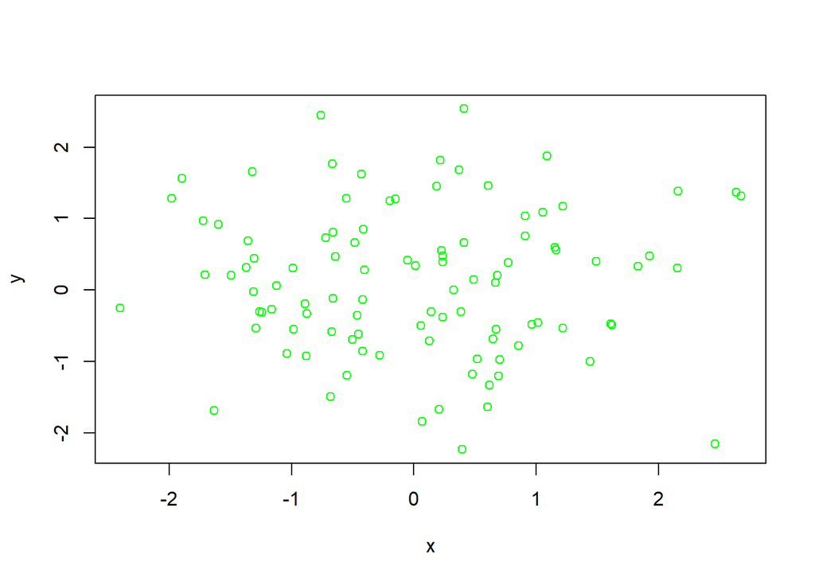

```r
x=rnorm(100)
y=rnorm(100)
plot(x,y, col="green")
```

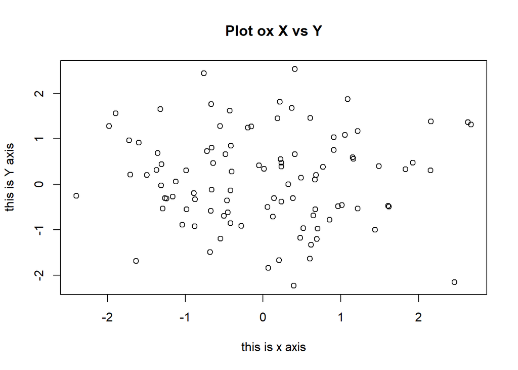

```r
plot(x,y,xlab = "this is x axis", ylab = "this is Y axis", main="Plot ox X vs Y")
```

**Seq()**

```r
x=seq(1,10)
x
```

```
##  [1]  1  2  3  4  5  6  7  8  9 10
```

```r
y=1:10
y
```

```
##  [1]  1  2  3  4  5  6  7  8  9 10
```

```r
z=seq(-pi,pi,length=50)
z
```

```
##  [1] -3.14159265 -3.01336438 -2.88513611 -2.75690784 -2.62867957 -2.50045130
##  [7] -2.37222302 -2.24399475 -2.11576648 -1.98753821 -1.85930994 -1.73108167
## [13] -1.60285339 -1.47462512 -1.34639685 -1.21816858 -1.08994031 -0.96171204
## [19] -0.83348377 -0.70525549 -0.57702722 -0.44879895 -0.32057068 -0.19234241
## [25] -0.06411414  0.06411414  0.19234241  0.32057068  0.44879895  0.57702722
## [31]  0.70525549  0.83348377  0.96171204  1.08994031  1.21816858  1.34639685
## [37]  1.47462512  1.60285339  1.73108167  1.85930994  1.98753821  2.11576648
## [43]  2.24399475  2.37222302  2.50045130  2.62867957  2.75690784  2.88513611
## [49]  3.01336438  3.14159265
```

**contour() for 3d graphs**

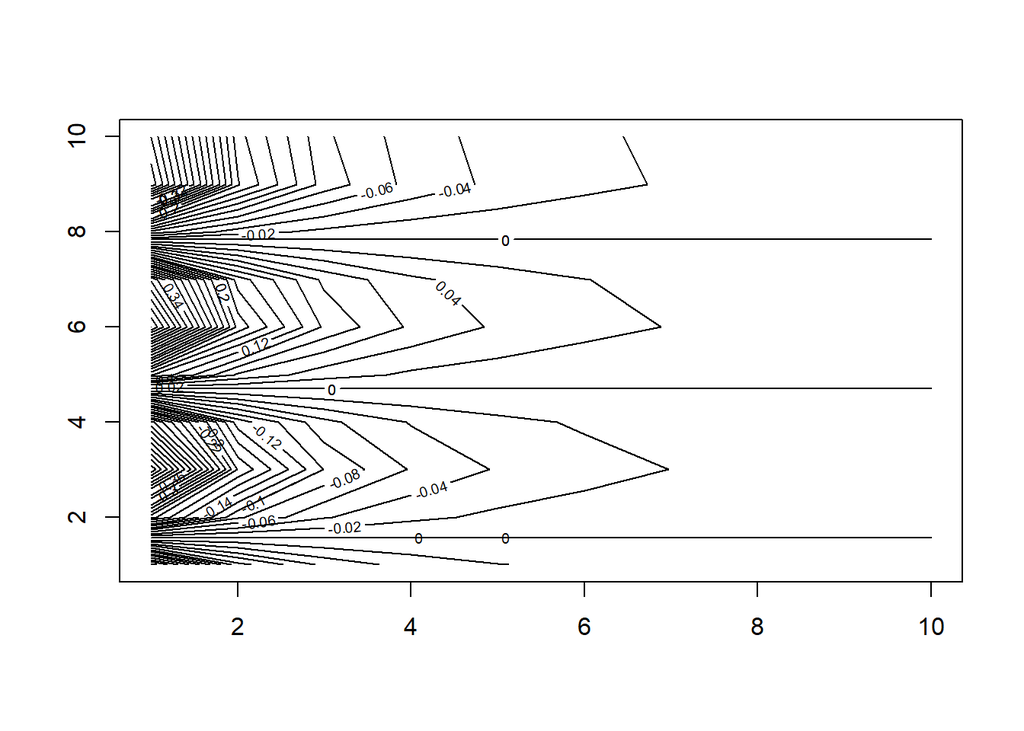

```r
y=x
f= outer(x,y, function(x,y) cos(y)/(1+x^2))
contour(x,y,f)
contour(x,y,f , nlevels = 45 , add = T)
```

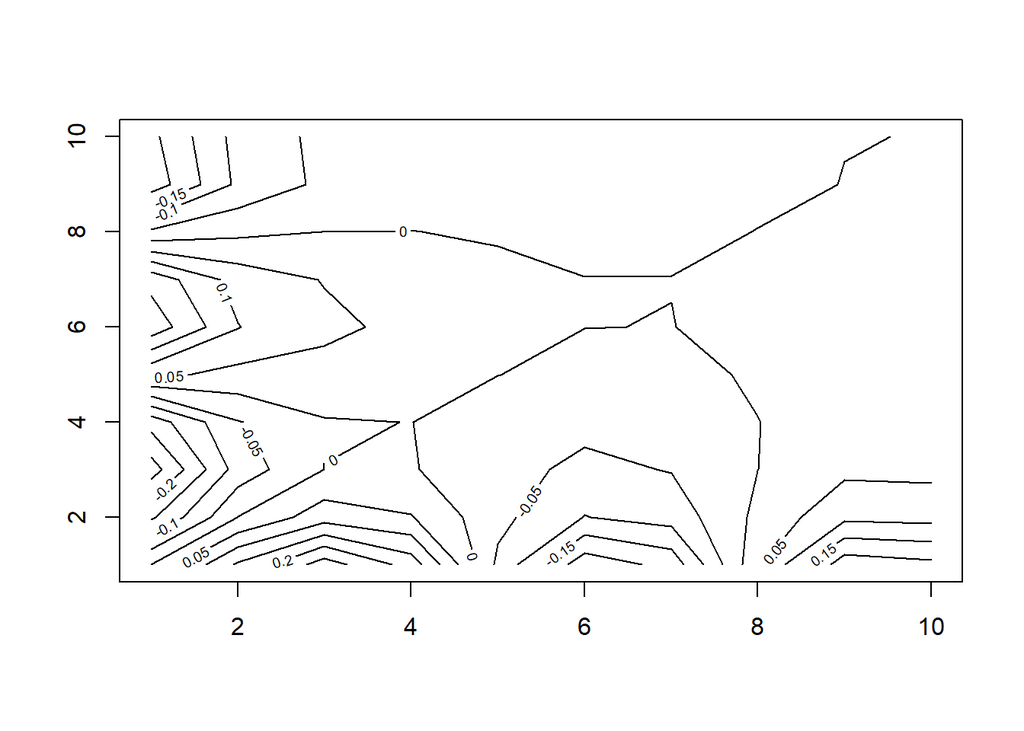

```r
fa=(f-t(f))/2
contour(x,y,fa,nlevels = 15)
```

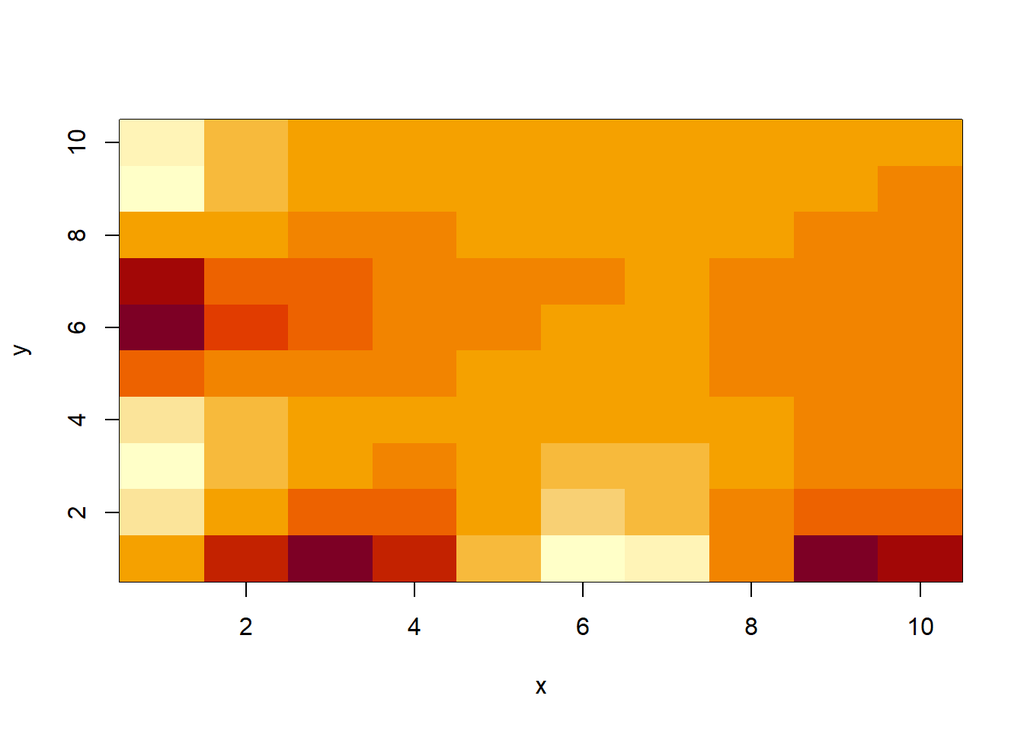

```r
image(x,y,fa)
```

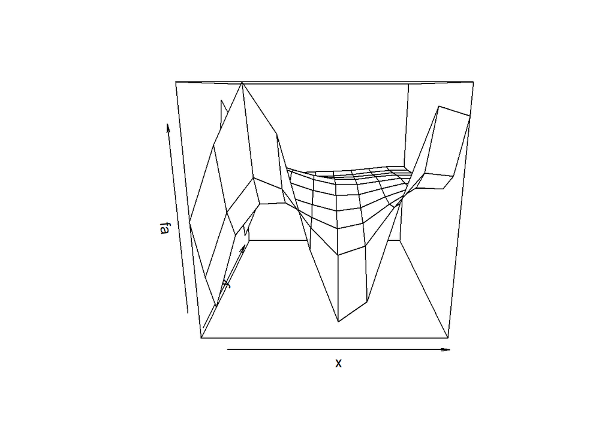

```r
persp(x,y,fa)
```

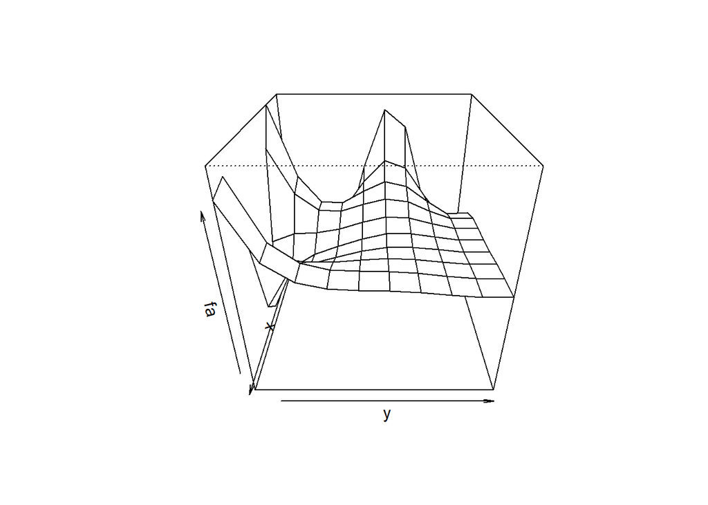

```r
persp(x,y,fa, theta = 90, phi=30)
```

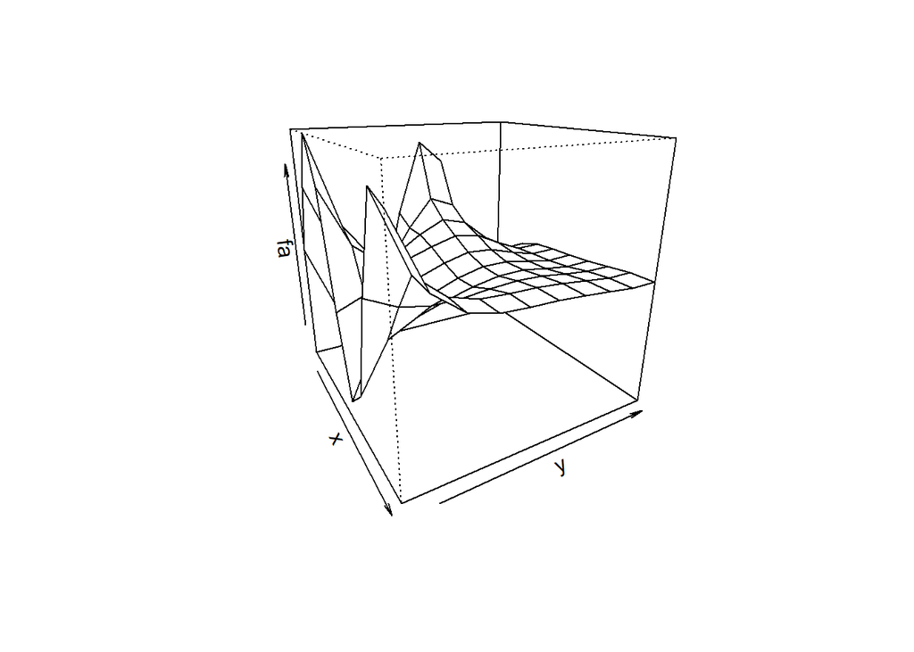

```r
persp(x,y,fa, theta = 60, phi=20)
```

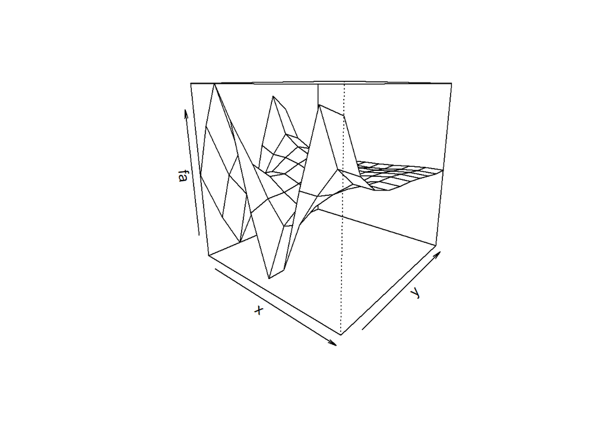

```r
persp(x,y,fa, theta = 40, phi=15)
```

### Indexing data

```r
A= matrix(1:16, 4,4)
A
```

```
##      [,1] [,2] [,3] [,4]
## [1,]    1    5    9   13
## [2,]    2    6   10   14
## [3,]    3    7   11   15
## [4,]    4    8   12   16
```

```r
A[2,3]
```

```
## [1] 10
```

```r
A[c(1,3),c(2,4)]
```

```
##      [,1] [,2]
## [1,]    5   13
## [2,]    7   15
```

```r
A[1:3,2:4]
```

```
##      [,1] [,2] [,3]
## [1,]    5    9   13
## [2,]    6   10   14
## [3,]    7   11   15
```

```r
A[1:2,]
```

```
##      [,1] [,2] [,3] [,4]
## [1,]    1    5    9   13
## [2,]    2    6   10   14
```

```r
A[,1:2]
```

```
##      [,1] [,2]
## [1,]    1    5
## [2,]    2    6
## [3,]    3    7
## [4,]    4    8
```

```r
A[1,]
```

```
## [1]  1  5  9 13
```

-ve sign indicates that select all the elements Except those mentioned , it is like a negation

```r
A
```

```
##      [,1] [,2] [,3] [,4]
## [1,]    1    5    9   13
## [2,]    2    6   10   14
## [3,]    3    7   11   15
## [4,]    4    8   12   16
```

```r
A[c(1,3),]
```

```
##      [,1] [,2] [,3] [,4]
## [1,]    1    5    9   13
## [2,]    3    7   11   15
```

```r
A[-c(1,3),]#second and last row
```

```
##      [,1] [,2] [,3] [,4]
## [1,]    2    6   10   14
## [2,]    4    8   12   16
```

```r
A[-c(1,3),-c(1,3,4)]
```

```
## [1] 6 8
```

```r
dim(A)
```

```
## [1] 4 4
```

### Loading Data

```r
Auto = read.table("Auto.data")
#View(Auto)
head(Auto)
```

```
##     V1        V2           V3         V4     V5           V6   V7     V8
## 1  mpg cylinders displacement horsepower weight acceleration year origin
## 2 18.0         8        307.0      130.0  3504.         12.0   70      1
## 3 15.0         8        350.0      165.0  3693.         11.5   70      1
## 4 18.0         8        318.0      150.0  3436.         11.0   70      1
## 5 16.0         8        304.0      150.0  3433.         12.0   70      1
## 6 17.0         8        302.0      140.0  3449.         10.5   70      1
##                          V9
## 1                      name
## 2 chevrolet chevelle malibu
## 3         buick skylark 320
## 4        plymouth satellite
## 5             amc rebel sst
## 6               ford torino
```

```r
Auto = read.table("Auto.data", na.strings = "?", header = T , stringsAsFactors = T )
head(Auto)
```

```
##   mpg cylinders displacement horsepower weight acceleration year origin
## 1  18         8          307        130   3504         12.0   70      1
## 2  15         8          350        165   3693         11.5   70      1
## 3  18         8          318        150   3436         11.0   70      1
## 4  16         8          304        150   3433         12.0   70      1
## 5  17         8          302        140   3449         10.5   70      1
## 6  15         8          429        198   4341         10.0   70      1
##                        name
## 1 chevrolet chevelle malibu
## 2         buick skylark 320
## 3        plymouth satellite
## 4             amc rebel sst
## 5               ford torino
## 6          ford galaxie 500
```

```r
Auto = read.csv("Auto.csv", na.strings = "?", stringsAsFactors = T)
attach(Auto)
head(Auto)
```

```
##   mpg cylinders displacement horsepower weight acceleration year origin
## 1  18         8          307        130   3504         12.0   70      1
## 2  15         8          350        165   3693         11.5   70      1
## 3  18         8          318        150   3436         11.0   70      1
## 4  16         8          304        150   3433         12.0   70      1
## 5  17         8          302        140   3449         10.5   70      1
## 6  15         8          429        198   4341         10.0   70      1
##                        name
## 1 chevrolet chevelle malibu
## 2         buick skylark 320
## 3        plymouth satellite
## 4             amc rebel sst
## 5               ford torino
## 6          ford galaxie 500
```

the strings as factors argument tells that if the value is string , treat the variable as qualitative

```r
dim(Auto)
```

```
## [1] 397   9
```

```r
Auto[1:4,]
```

```
##   mpg cylinders displacement horsepower weight acceleration year origin
## 1  18         8          307        130   3504         12.0   70      1
## 2  15         8          350        165   3693         11.5   70      1
## 3  18         8          318        150   3436         11.0   70      1
## 4  16         8          304        150   3433         12.0   70      1
##                        name
## 1 chevrolet chevelle malibu
## 2         buick skylark 320
## 3        plymouth satellite
## 4             amc rebel sst
```

```r
Auto= na.omit(Auto)
dim(Auto) #as we see number of rows are reduced
```

```
## [1] 392   9
```

```r
names(Auto)
```

```
## [1] "mpg"          "cylinders"    "displacement" "horsepower"   "weight"
## [6] "acceleration" "year"         "origin"       "name"
```

#### Additional graphical and numerical Summaries

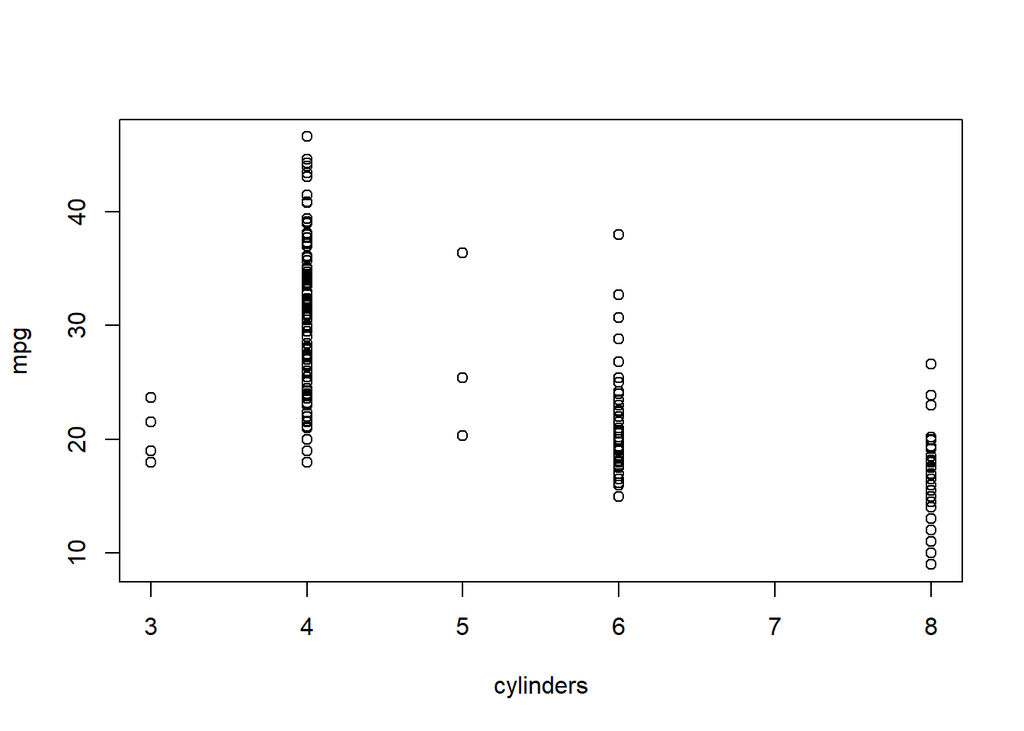

```r
plot(cylinders,mpg)
```

```r
#the cylinders is quantitative
```

The **as.factor() function converts quantitative variables into qualitative** variables.

```r
cylinders= as.factor(cylinders)
```

*If the variable plotted on the x-axis is qualitative, then boxplots will automatically be produced by the plot() function.*

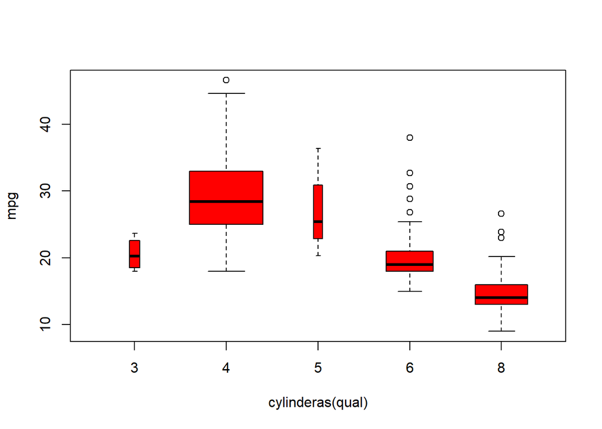

```r
plot(cylinders, mpg , xlab="cylinderas(qual)", ylab="mpg", col="red", varwidth=T, horizontal=F)
```

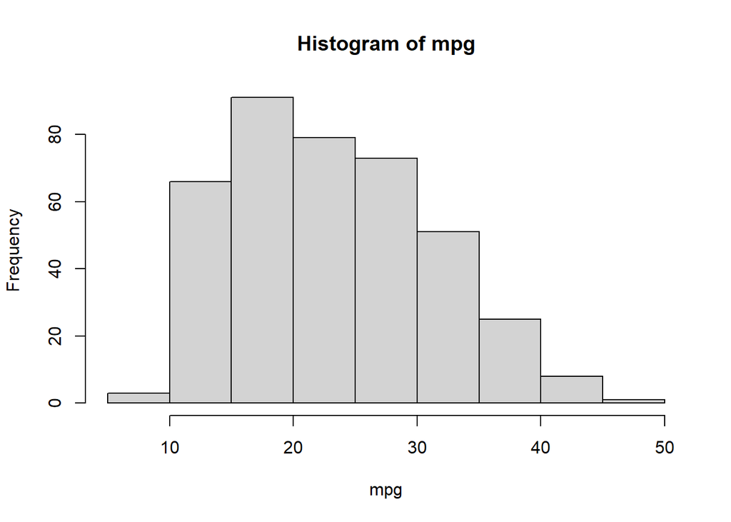

```r
hist(mpg)
```

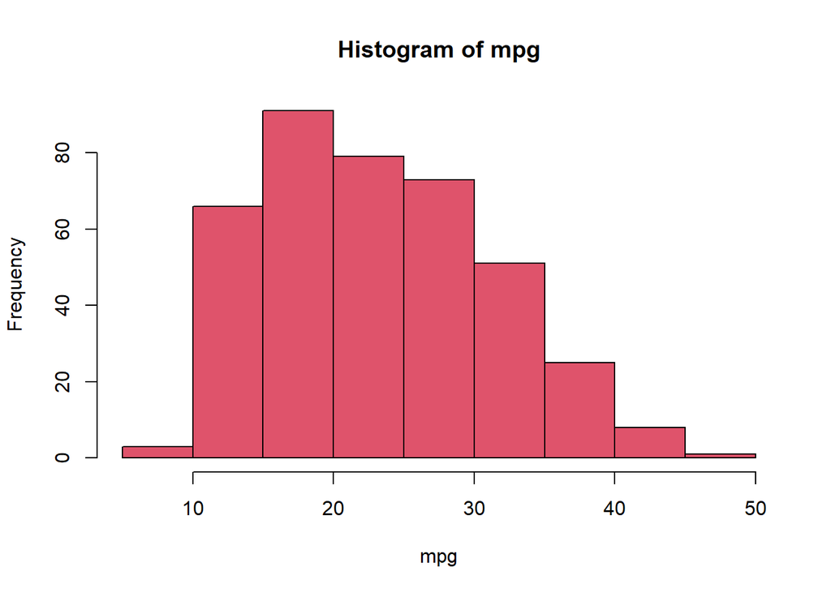

```r
hist(mpg, col=2)
```

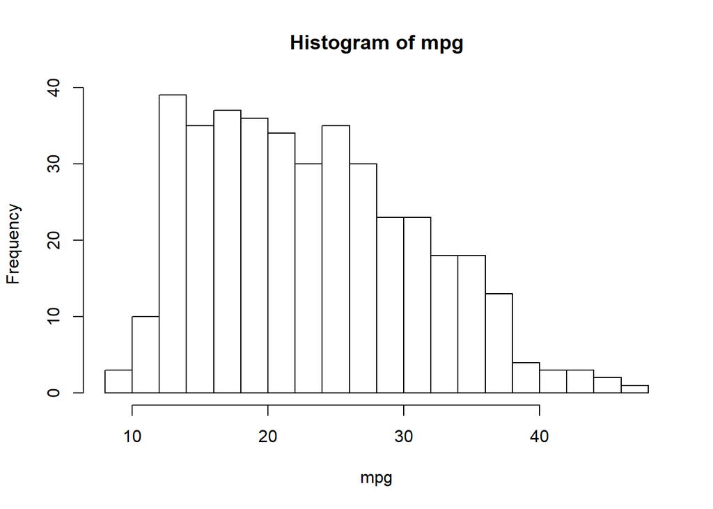

```r
hist(mpg,col=0, breaks=15)
```

The **pairs()** function creates a scatterplotmatrix, i.e. a scatterplot for every pair of variables.

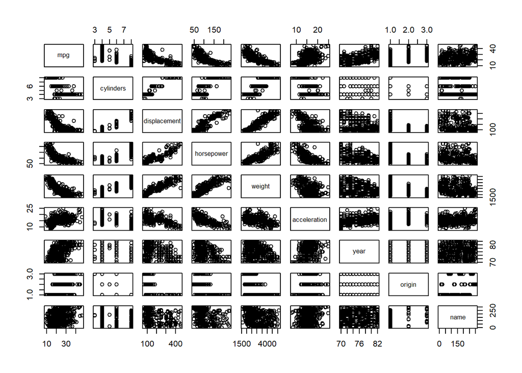

```r
pairs(Auto)
```

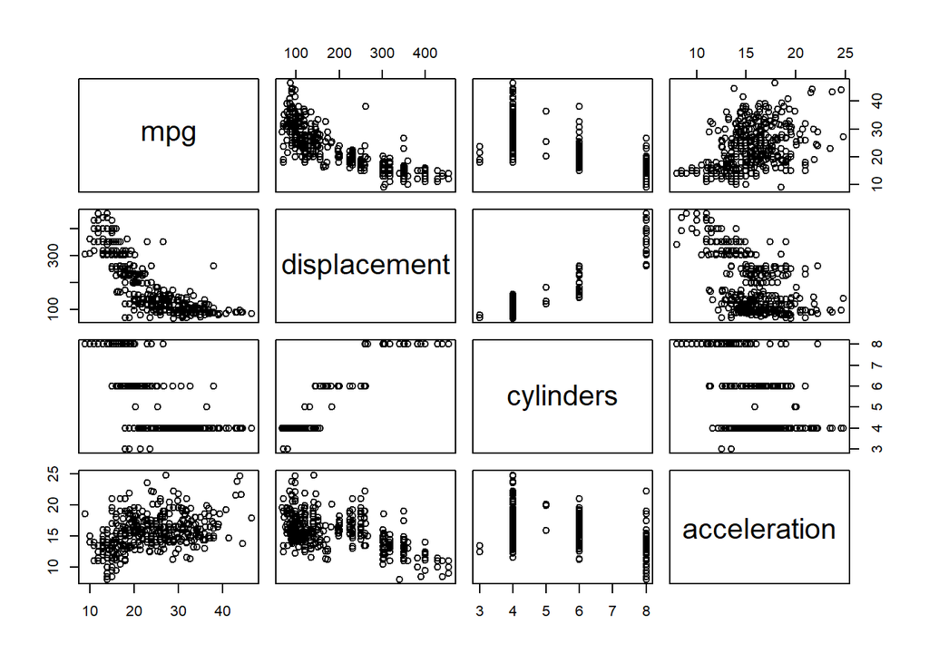

```r
pairs(~mpg + displacement + cylinders + acceleration, data=Auto)
```

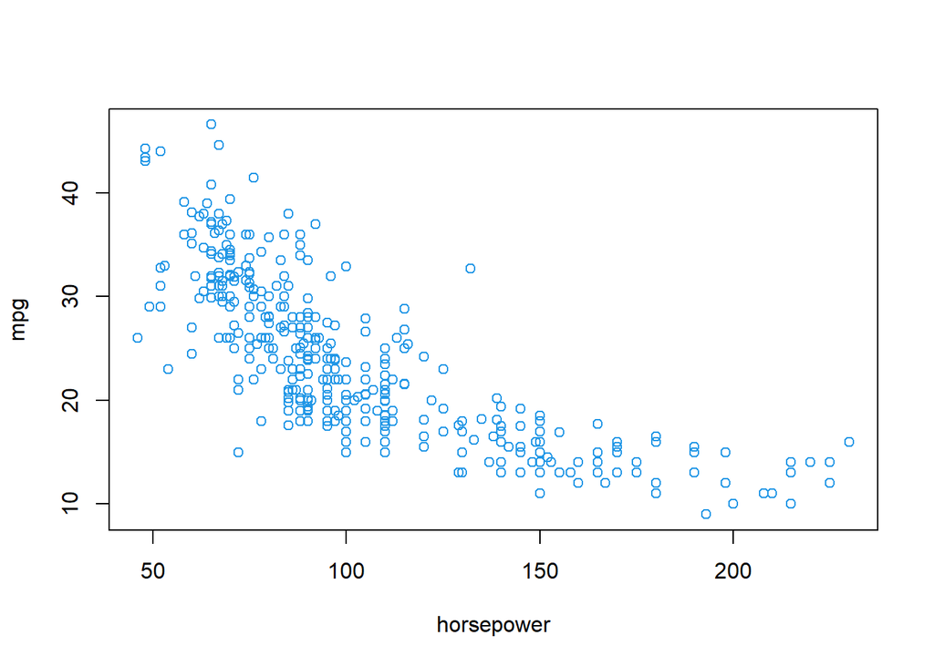

```r
#windows()
plot(horsepower,mpg, col=12)
```

```r
#identify(horsepower, mpg , name)
```

Use windows() to run the identify interactive function

```r
summary(Auto)
```

```
##       mpg          cylinders      displacement     horsepower        weight
##  Min.   : 9.00   Min.   :3.000   Min.   : 68.0   Min.   : 46.0   Min.   :1613
##  1st Qu.:17.00   1st Qu.:4.000   1st Qu.:105.0   1st Qu.: 75.0   1st Qu.:2225
##  Median :22.75   Median :4.000   Median :151.0   Median : 93.5   Median :2804
##  Mean   :23.45   Mean   :5.472   Mean   :194.4   Mean   :104.5   Mean   :2978
##  3rd Qu.:29.00   3rd Qu.:8.000   3rd Qu.:275.8   3rd Qu.:126.0   3rd Qu.:3615
##  Max.   :46.60   Max.   :8.000   Max.   :455.0   Max.   :230.0   Max.   :5140
##
##   acceleration        year           origin                      name
##  Min.   : 8.00   Min.   :70.00   Min.   :1.000   amc matador       :  5
##  1st Qu.:13.78   1st Qu.:73.00   1st Qu.:1.000   ford pinto        :  5
##  Median :15.50   Median :76.00   Median :1.000   toyota corolla    :  5
##  Mean   :15.54   Mean   :75.98   Mean   :1.577   amc gremlin       :  4
##  3rd Qu.:17.02   3rd Qu.:79.00   3rd Qu.:2.000   amc hornet        :  4
##  Max.   :24.80   Max.   :82.00   Max.   :3.000   chevrolet chevette:  4
##                                                  (Other)           :365
```

```r
summary(displacement)
```

```
##    Min. 1st Qu.  Median    Mean 3rd Qu.    Max.
##    68.0   104.0   146.0   193.5   262.0   455.0
```

## APPLIED EXERCISE

8. This exercise relates to the College data set, which can be found in the file College.csv on the book website. It contains a number of variables for 777 different universities and colleges in the US
1. Use the read.csv() function to read the data into R. Call the loaded data college. Make sure that you have the directory set to the correct location for the data.

```r
college = read.csv("College.csv" ,stringsAsFactors = T )
attach(college)
View(college)
dim(college)
```

```
## [1] 777  19
```

2. Look at the data using the View() function. You should notice that the first column is just the name of each university. We don’t really want R to treat this as data.

```r
rownames(college)= college[,1]
college = college[,-1]
```

3. 1. Use the summary() function to produce a numerical summary of the variables in the data set.

```r
summary(college)
```

```
##  Private        Apps           Accept          Enroll       Top10perc
##  No :212   Min.   :   81   Min.   :   72   Min.   :  35   Min.   : 1.00
##  Yes:565   1st Qu.:  776   1st Qu.:  604   1st Qu.: 242   1st Qu.:15.00
##            Median : 1558   Median : 1110   Median : 434   Median :23.00
##            Mean   : 3002   Mean   : 2019   Mean   : 780   Mean   :27.56
##            3rd Qu.: 3624   3rd Qu.: 2424   3rd Qu.: 902   3rd Qu.:35.00
##            Max.   :48094   Max.   :26330   Max.   :6392   Max.   :96.00
##    Top25perc      F.Undergrad     P.Undergrad         Outstate
##  Min.   :  9.0   Min.   :  139   Min.   :    1.0   Min.   : 2340
##  1st Qu.: 41.0   1st Qu.:  992   1st Qu.:   95.0   1st Qu.: 7320
##  Median : 54.0   Median : 1707   Median :  353.0   Median : 9990
##  Mean   : 55.8   Mean   : 3700   Mean   :  855.3   Mean   :10441
##  3rd Qu.: 69.0   3rd Qu.: 4005   3rd Qu.:  967.0   3rd Qu.:12925
##  Max.   :100.0   Max.   :31643   Max.   :21836.0   Max.   :21700
##    Room.Board       Books           Personal         PhD
##  Min.   :1780   Min.   :  96.0   Min.   : 250   Min.   :  8.00
##  1st Qu.:3597   1st Qu.: 470.0   1st Qu.: 850   1st Qu.: 62.00
##  Median :4200   Median : 500.0   Median :1200   Median : 75.00
##  Mean   :4358   Mean   : 549.4   Mean   :1341   Mean   : 72.66
##  3rd Qu.:5050   3rd Qu.: 600.0   3rd Qu.:1700   3rd Qu.: 85.00
##  Max.   :8124   Max.   :2340.0   Max.   :6800   Max.   :103.00
##     Terminal       S.F.Ratio      perc.alumni        Expend
##  Min.   : 24.0   Min.   : 2.50   Min.   : 0.00   Min.   : 3186
##  1st Qu.: 71.0   1st Qu.:11.50   1st Qu.:13.00   1st Qu.: 6751
##  Median : 82.0   Median :13.60   Median :21.00   Median : 8377
##  Mean   : 79.7   Mean   :14.09   Mean   :22.74   Mean   : 9660
##  3rd Qu.: 92.0   3rd Qu.:16.50   3rd Qu.:31.00   3rd Qu.:10830
##  Max.   :100.0   Max.   :39.80   Max.   :64.00   Max.   :56233
##    Grad.Rate
##  Min.   : 10.00
##  1st Qu.: 53.00
##  Median : 65.00
##  Mean   : 65.46
##  3rd Qu.: 78.00
##  Max.   :118.00
```

```r
names(college)
```

```
##  [1] "Private"     "Apps"        "Accept"      "Enroll"      "Top10perc"
##  [6] "Top25perc"   "F.Undergrad" "P.Undergrad" "Outstate"    "Room.Board"
## [11] "Books"       "Personal"    "PhD"         "Terminal"    "S.F.Ratio"
## [16] "perc.alumni" "Expend"      "Grad.Rate"
```

ii. Use the pairs() function to produce a scatterplot matrix of the first ten columns or variables of the data. Recall that you can reference the first ten columns of a matrix A using A[,1:10].

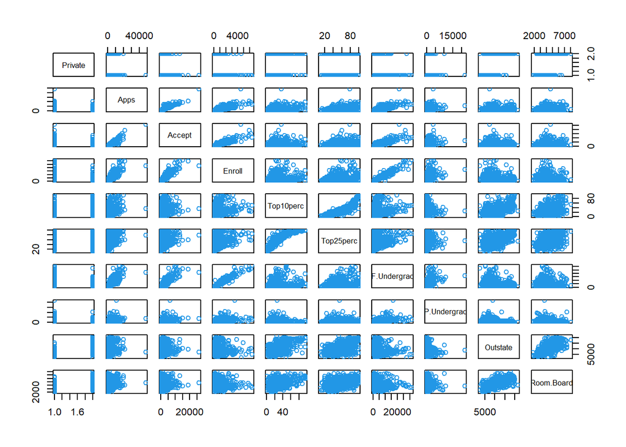

```r
pairs(college[,1:10], col=12)
```

3. Use the plot() function to produce side-by-side boxplots of Outstate versus Private.

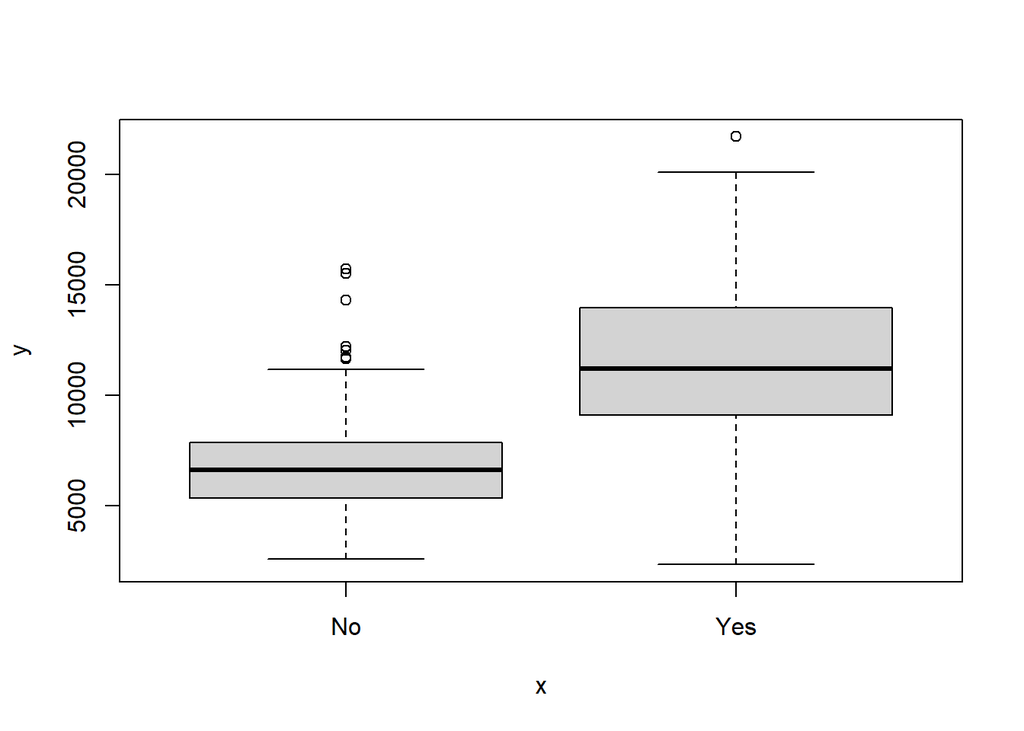

```r
plot(Private, Outstate)
```

*Here we can see that in average Private Institutes have more out of state tuition*

**iv.** Create a new qualitative variable, called Elite, by binning the Top10perc variable. We are going to divide universities into two groups based on whether or not the proportion of students coming from the top 10% of their high school classes exceeds 50%.

```r
if (!("Elite" %in% colnames(college))) {
  Elite = rep("No", nrow(college))
Elite[Top10perc>50]= "Yes"
Elite=as.factor(Elite)
college=data.frame(college,Elite)
}

head(college)
```

```
##                              Private Apps Accept Enroll Top10perc Top25perc
## Abilene Christian University     Yes 1660   1232    721        23        52
## Adelphi University               Yes 2186   1924    512        16        29
## Adrian College                   Yes 1428   1097    336        22        50
## Agnes Scott College              Yes  417    349    137        60        89
## Alaska Pacific University        Yes  193    146     55        16        44
## Albertson College                Yes  587    479    158        38        62
##                              F.Undergrad P.Undergrad Outstate Room.Board Books
## Abilene Christian University        2885         537     7440       3300   450
## Adelphi University                  2683        1227    12280       6450   750
## Adrian College                      1036          99    11250       3750   400
## Agnes Scott College                  510          63    12960       5450   450
## Alaska Pacific University            249         869     7560       4120   800
## Albertson College                    678          41    13500       3335   500
##                              Personal PhD Terminal S.F.Ratio perc.alumni Expend
## Abilene Christian University     2200  70       78      18.1          12   7041
## Adelphi University               1500  29       30      12.2          16  10527
## Adrian College                   1165  53       66      12.9          30   8735
## Agnes Scott College               875  92       97       7.7          37  19016
## Alaska Pacific University        1500  76       72      11.9           2  10922
## Albertson College                 675  67       73       9.4          11   9727
##                              Grad.Rate Elite
## Abilene Christian University        60    No
## Adelphi University                  56    No
## Adrian College                      54    No
## Agnes Scott College                 59   Yes
## Alaska Pacific University           15    No
## Albertson College                   55    No
```

Use the summary() function to see how many elite universities there are. Now use the plot() function to produce side-by-side boxplots of Outstate versus Elite.

```r
summary(Elite)
```

```
##  No Yes
## 699  78
```

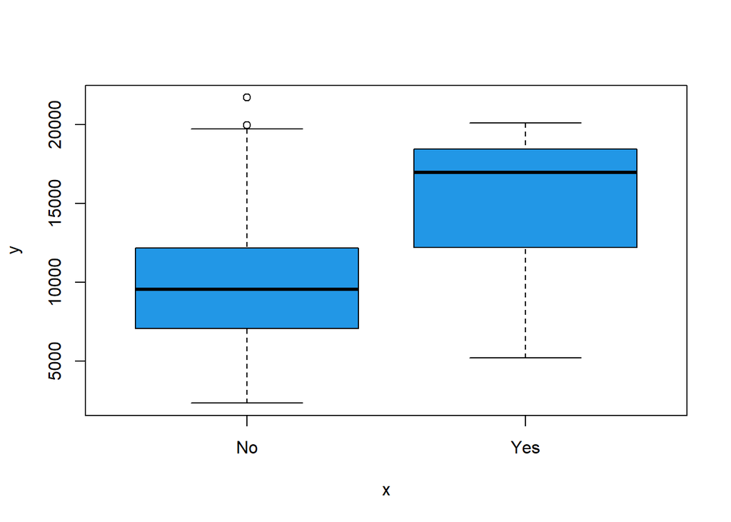

```r
plot(Elite,Outstate, col=12)
```

*So in average elite people have more out of state tuition*

**v.** Use the hist() function to produce some histograms with differing numbers of bins for a few of the quantitative variables. You may find the command par(mfrow = c(2, 2)) useful: it will divide the print window into four regions so that four plots can be made simultaneously. Modifying the arguments to this function will divide the screen in other ways.

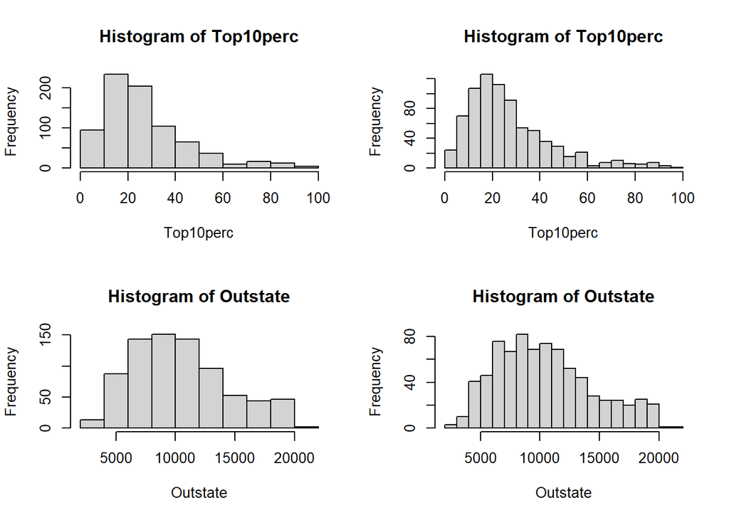

```r
par(mfrow=c(2,2))
hist(Top10perc)
hist(Top10perc, breaks = 15)
hist(Outstate)
hist(Outstate, breaks=15)
```

**vi. Continue exploring the data, and provide a brief summary of what you discover.**

**9.** This exercise involves the Auto data set studied in the lab. Make sure that the missing values have been removed from the data. **(a)** Which of the predictors are quantitative, and which are qualitative?

```r
head(Auto)
```

```
##   mpg cylinders displacement horsepower weight acceleration year origin
## 1  18         8          307        130   3504         12.0   70      1
## 2  15         8          350        165   3693         11.5   70      1
## 3  18         8          318        150   3436         11.0   70      1
## 4  16         8          304        150   3433         12.0   70      1
## 5  17         8          302        140   3449         10.5   70      1
## 6  15         8          429        198   4341         10.0   70      1
##                        name
## 1 chevrolet chevelle malibu
## 2         buick skylark 320
## 3        plymouth satellite
## 4             amc rebel sst
## 5               ford torino
## 6          ford galaxie 500
```

```r
Auto= na.omit(Auto)
```

*Quantitative- mpg, cylinders, displacement, horsepower, weight, acceleration,*

*Qualitative - Year, Origin, name*

2. What is the range of each quantitative predictor? You can answer this using the range() function.

```r
cylinders= as.numeric(as.character(cylinders))
range(mpg)
```

```
## [1]  9.0 46.6
```

```r
range(cylinders)
```

```
## [1] 3 8
```

```r
range(displacement)
```

```
## [1]  68 455
```

```r
range(horsepower, na.rm=T)
```

```
## [1]  46 230
```

```r
range(weight)
```

```
## [1] 1613 5140
```

```r
range(acceleration)
```

```
## [1]  8.0 24.8
```

3. What is the mean and standard deviation of each quantitative predictor?

```r
cat("MPG Mean:", mean(mpg), "\n")
```

```
## MPG Mean: 23.51587
```

```r
cat("MPG SD:", sd(mpg), "\n")
```

```
## MPG SD: 7.825804
```

```r
cat("displacement Mean:", mean(displacement), "\n")
```

```
## displacement Mean: 193.5327
```

```r
cat("displacement SD:", sd(displacement), "\n")
```

```
## displacement SD: 104.3796
```

```r
cat("weight Mean:", mean(weight), "\n")
```

```
## weight Mean: 2970.262
```

```r
cat("weight SD:", sd(weight), "\n")
```

```
## weight SD: 847.9041
```

```r
cat("horsepower Mean:", mean(horsepower), "\n")
```

```
## horsepower Mean: NA
```

```r
cat("horsepower SD:", sd(horsepower), "\n")
```

```
## horsepower SD: NA
```

```r
cat("acceleration Mean:", mean(acceleration), "\n")
```

```
## acceleration Mean: 15.55567
```

```r
cat("acceleration SD:", sd(acceleration), "\n")
```

```
## acceleration SD: 2.749995
```

4. Now remove the 10th through 85th observations. What is the mean, and standard deviation of each predictor in the subset of the data that remains?

```r
Autosubset = Auto[-c(10:84),]
```

```r
with(Autosubset,{
cat("MPG Mean:", mean(mpg), "\n")
cat("MPG SD:", sd(mpg), "\n")
cat("displacement Mean:", mean(displacement), "\n")
cat("displacement SD:", sd(displacement), "\n")
cat("weight Mean:", mean(weight), "\n")
cat("weight SD:", sd(weight), "\n")
cat("horsepower Mean:", mean(horsepower), "\n")
cat("horsepower SD:", sd(horsepower), "\n")
cat("acceleration Mean:", mean(acceleration), "\n")
cat("acceleration SD:", sd(acceleration), "\n")})
```

```
## MPG Mean: 24.36845
## MPG SD: 7.880898
## displacement Mean: 187.7539
## displacement SD: 99.93949
## weight Mean: 2939.644
## weight SD: 812.6496
## horsepower Mean: 100.9558
## horsepower SD: 35.89557
## acceleration Mean: 15.7183
## acceleration SD: 2.693813
```

**e),f)** are similar - Suppose that we wish to predict gas mileage (mpg) on the basis of the other variables. Do your plots suggest that any of the other variables might be useful in predicting mpg? Justify your answer.

```r
colnames(Auto)
```

```
## [1] "mpg"          "cylinders"    "displacement" "horsepower"   "weight"
## [6] "acceleration" "year"         "origin"       "name"
```

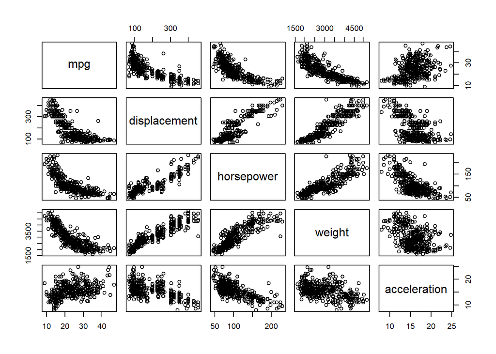

```r
plot(~mpg + displacement + horsepower + weight + acceleration)
```

*we can see mpg is linearly corelated with displacement , horsepower and weight ; so these can be used as predictors for mpg , checking for corelation values*

```r
Auto$horsepower[Auto$horsepower == "?"] <- NA
Auto$horsepower <- as.numeric(Auto$horsepower)
Auto <- na.omit(Auto)
with(Auto, {
  cat("mpg vs displacement:", cor(mpg, displacement), "\n")
  cat("mpg vs horsepower:",  cor(mpg, horsepower), "\n")
  cat("mpg vs weight:",      cor(mpg, weight), "\n")
  cat("mpg vs acceleration:", cor(mpg, acceleration), "\n")
})
```

```
## mpg vs displacement: -0.8051269
## mpg vs horsepower: -0.7784268
## mpg vs weight: -0.8322442
## mpg vs acceleration: 0.4233285
```

*as we can see apart from acceleration , rest all have high correlation values*

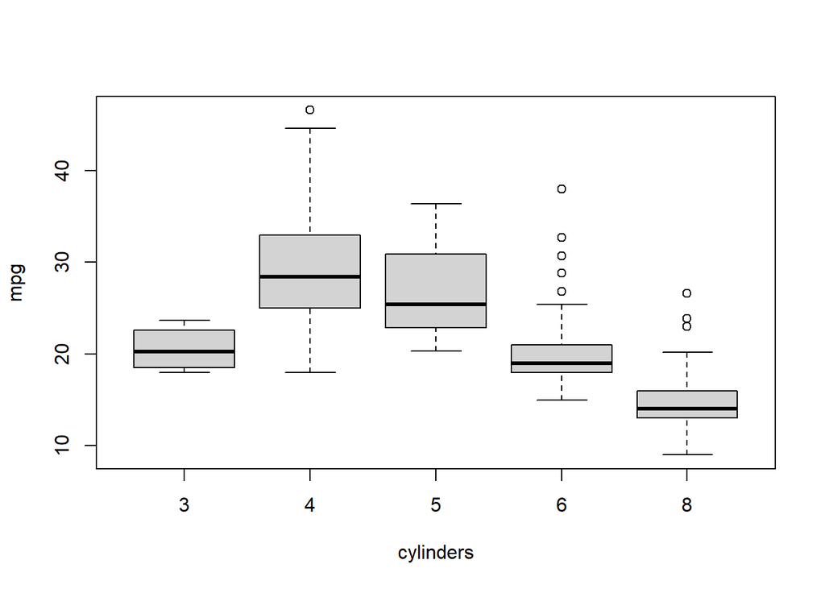

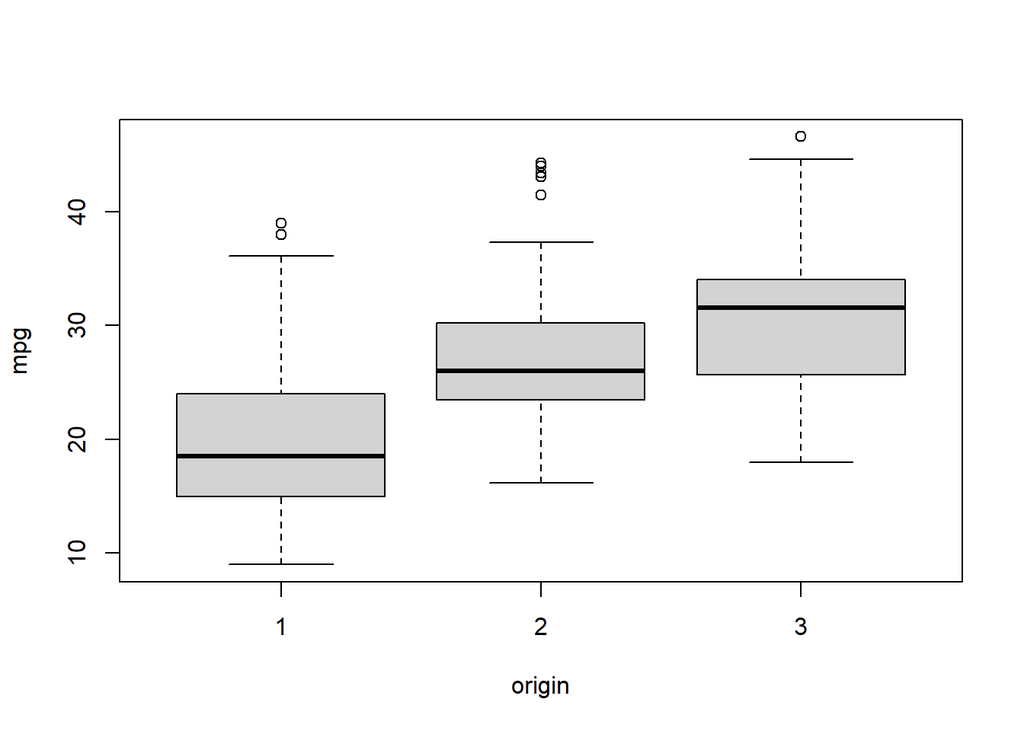

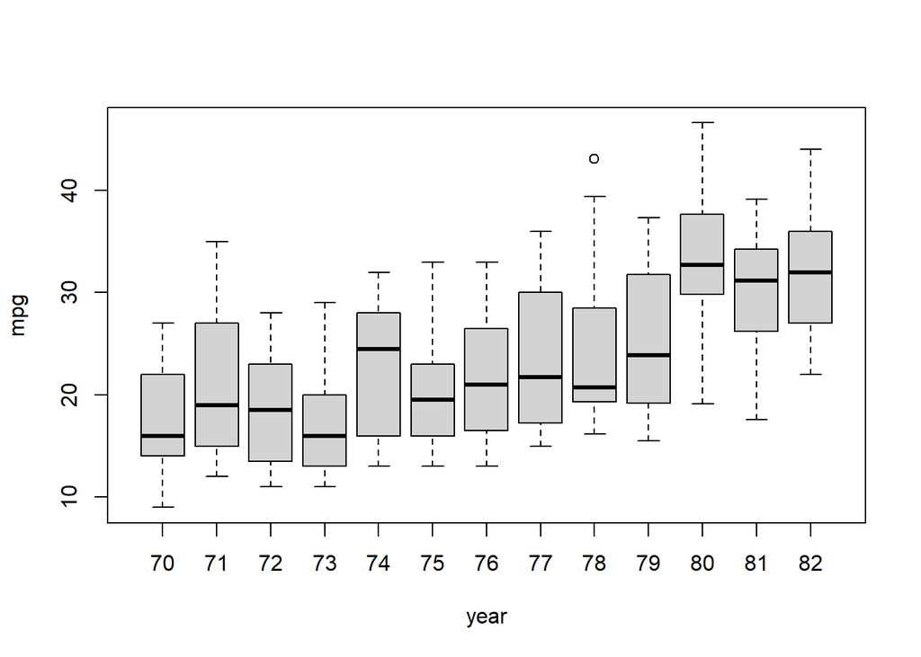

```r
with(Auto,{
  cylinders= as.factor(cylinders)
  year= as.factor(year)
  origin= as.factor(origin)
  plot(cylinders,mpg, xlab = "cylinders", ylab = "mpg")
  plot(origin,mpg, xlab="origin", ylab="mpg")
  plot(year,mpg, xlab="year", ylab="mpg")})
```

*From the first plot we can see that 4 cylinders usually achieve a higher general mpg and it decreases as the number of cylinders increase, we can say that having 4 cylinders might be most efficient*

*Second plot tells us (1- american, 2-European, 3- Japanese) that highest level of mpg is achieved by Japanese origin cars and least by american , although German cars are moderately efficient , they do have some outliers that are achieve High mpg and are highly efficient*

*Lastly, the third plot of year vs mpg showcases that cars manufactured later in the 80s are more efficient and have high mpg than earlier manufactured cars.*

**10.** This exercise involves the Boston housing data set. **(a)** To begin, load in the Boston data set. The Boston data set is part of the ISLR2 library.

```r
if (!requireNamespace("ISLR2", quietly = TRUE)) {
  install.packages("ISLR2")
}
library(ISLR2)
```

How many rows are in this data set? How many columns? What do the rows and columns represent?

```r
dim(Boston)
```

```
## [1] 506  13
```

```r
colnames(Boston)
```

```
##  [1] "crim"    "zn"      "indus"   "chas"    "nox"     "rm"      "age"
##  [8] "dis"     "rad"     "tax"     "ptratio" "lstat"   "medv"
```

*506 rows and 13 columns*

**`crim`**

per capita crime rate by town.

**`zn`**

proportion of residential land zoned for lots over 25,000 sq.ft.

**`indus`**

proportion of non-retail business acres per town.

**`chas`**

Charles River dummy variable (= 1 if tract bounds river; 0 otherwise).

**`nox`**

nitrogen oxides concentration (parts per 10 million).

**`rm`**

average number of rooms per dwelling.

**`age`**

proportion of owner-occupied units built prior to 1940.

**`dis`**

weighted mean of distances to five Boston employment centres.

**`rad`**

index of accessibility to radial highways.

**`tax`**

full-value property-tax rate per $10,000.

**`ptratio`**

pupil-teacher ratio by town.

**`lstat`**

lower status of the population (percent).

**`medv`**

median value of owner-occupied homes in $1000s.

**(b)** Make some pairwise scatterplots of the predictors (columns) in this data set. Describe your findings.

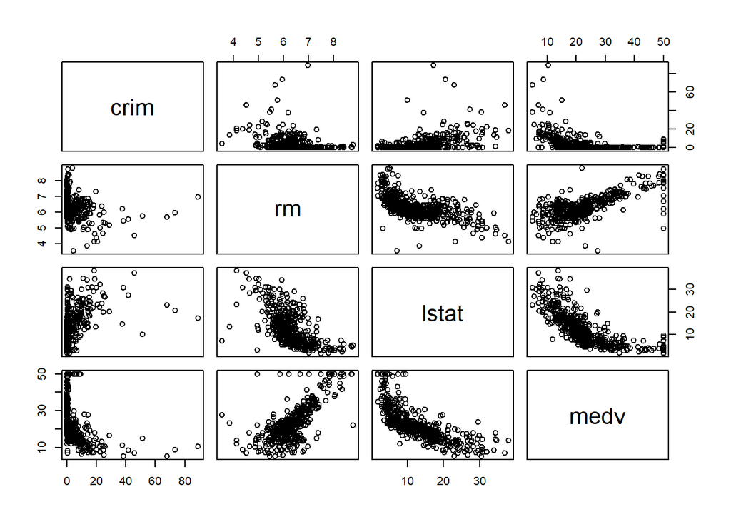

```r
pairs(Boston[, c("crim","rm","lstat","medv")])
```

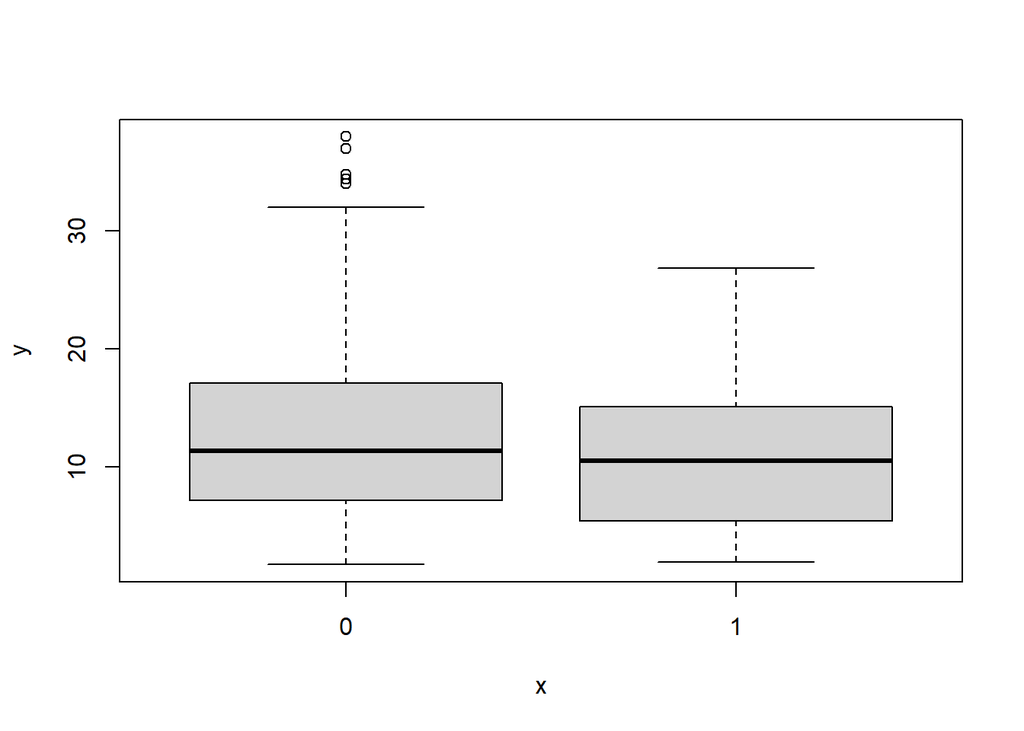

```r
Boston$chas = as.factor(Boston$chas)

plot(Boston$chas, Boston$lstat)
```

**(c)** Are any of the predictors associated with per capita crime rate? If so, explain the relationship.

```r
# Select only numeric columns
numeric_data <- Boston[, sapply(Boston, is.numeric)]

cor_matrix <- cor(numeric_data)


cor_matrix>0.7
```

```
##          crim    zn indus   nox    rm   age   dis   rad   tax ptratio lstat
## crim     TRUE FALSE FALSE FALSE FALSE FALSE FALSE FALSE FALSE   FALSE FALSE
## zn      FALSE  TRUE FALSE FALSE FALSE FALSE FALSE FALSE FALSE   FALSE FALSE
## indus   FALSE FALSE  TRUE  TRUE FALSE FALSE FALSE FALSE  TRUE   FALSE FALSE
## nox     FALSE FALSE  TRUE  TRUE FALSE  TRUE FALSE FALSE FALSE   FALSE FALSE
## rm      FALSE FALSE FALSE FALSE  TRUE FALSE FALSE FALSE FALSE   FALSE FALSE
## age     FALSE FALSE FALSE  TRUE FALSE  TRUE FALSE FALSE FALSE   FALSE FALSE
## dis     FALSE FALSE FALSE FALSE FALSE FALSE  TRUE FALSE FALSE   FALSE FALSE
## rad     FALSE FALSE FALSE FALSE FALSE FALSE FALSE  TRUE  TRUE   FALSE FALSE
## tax     FALSE FALSE  TRUE FALSE FALSE FALSE FALSE  TRUE  TRUE   FALSE FALSE
## ptratio FALSE FALSE FALSE FALSE FALSE FALSE FALSE FALSE FALSE    TRUE FALSE
## lstat   FALSE FALSE FALSE FALSE FALSE FALSE FALSE FALSE FALSE   FALSE  TRUE
## medv    FALSE FALSE FALSE FALSE FALSE FALSE FALSE FALSE FALSE   FALSE FALSE
##          medv
## crim    FALSE
## zn      FALSE
## indus   FALSE
## nox     FALSE
## rm      FALSE
## age     FALSE
## dis     FALSE
## rad     FALSE
## tax     FALSE
## ptratio FALSE
## lstat   FALSE
## medv     TRUE
```

*as we see from the first row , crim does not have a single strong correlation with any other predictor*